# Intro to RNASeq

Katie Owsiany, MD/PhD student

ko8xh@virginia.edu

[Back to the main page](https://bims8382.netlify.com/)

# Welcome to RNAseq analysis with DESeq2 workshop!

## Outline:

1. First we will go over the basics of how to preprocess sequencing data that you would get from the UVA genomics core, or another sequenicing service, to the point where we can analyize differential gene expression in R using DESeq2.
2. We will spend most of the time analyzing differential expression using DESeq2 in R
3. Then we will do KEGG and GO pathway analysis

Recommended reading and manuals: [DESeq2 paper](https://www.ncbi.nlm.nih.gov/pubmed/25516281) [source paper for our data](https://www.ncbi.nlm.nih.gov/pmc/articles/PMC4903174) [paper](https://www.ncbi.nlm.nih.gov/pubmed/24227677) and [manual](https://github.com/alexdobin/STAR/blob/master/doc/STARmanual.pdf) for STAR and [featureCounts](https://www.ncbi.nlm.nih.gov/pmc/articles/PMC4631051/)

First let’s go over preprocessing. The steps for this can vary a lot depending on the goals of your experiment and setup. But, to give you at least an overview of the steps involved, I’ll walk us though an analysis I did using sequencing output from UVA genomics core sequencing facility in class. A full discussion is available in an optional tutorials here and here

let’s load the packages we will need for analysis today

```r
library(tidyverse)

if (!requireNamespace("BiocManager", quietly = TRUE))
  install.packages("BiocManager")
BiocManager::install("DESeq2", version = "3.8")
##
## The downloaded binary packages are in
##  /var/folders/9g/c8hfg3nj7h7fwdl8m4sl7kq80000gn/T//RtmpfOVKyn/downloaded_packages
library(DESeq2)

BiocManager::install('recount')
##
## The downloaded binary packages are in
##  /var/folders/9g/c8hfg3nj7h7fwdl8m4sl7kq80000gn/T//RtmpfOVKyn/downloaded_packages
library(recount)

BiocManager::install('biomaRt')
##
## The downloaded binary packages are in
##  /var/folders/9g/c8hfg3nj7h7fwdl8m4sl7kq80000gn/T//RtmpfOVKyn/downloaded_packages
library(biomaRt)

BiocManager::install("gage")
##
## The downloaded binary packages are in
##  /var/folders/9g/c8hfg3nj7h7fwdl8m4sl7kq80000gn/T//RtmpfOVKyn/downloaded_packages
library(gage)

BiocManager::install("pathveiw")
## Warning: package 'pathveiw' is not available (for R version 3.5.2)
library(pathview)

BiocManager::install("gageData")
library(gageData)
```

After preprocessing, you should have a .txt file corresponding to counts of genes mapped by featureCounts in your samples. You can download these files from Rivanna to your computer using globus. However, today we will use a pre-processed count matrix available from [recounts](https://jhubiostatistics.shinyapps.io/recount/), which is a great database of publicly available pre-processed RNAseq data. Today we will be using data from [this paper](https://www.ncbi.nlm.nih.gov/pmc/articles/PMC4903174). They did an experiment comparing RNAseq transcripts regulated differently between circulating lymphatic and endothelial progenitor cells isolated from whole blood samples.

## Download studies from recount

Let’s load today’s study. Navigate to shiny app for the database [here](https://jhubiostatistics.shinyapps.io/recount/).

```r
endo <- download_study("SRP035883")
load(file.path('SRP035883', 'rse_gene.Rdata'))
rse<- scale_counts(rse_gene)
endo_counts <- assays(rse)$counts
head(endo_counts)
##                    SRR1145636 SRR1145638 SRR1145637 SRR1145639 SRR1145640
## ENSG00000000003.14       1507       1704       1274       1369       1548
## ENSG00000000005.5           0          0          0          0          0
## ENSG00000000419.12        829       1188        949        908       1014
## ENSG00000000457.13        312        370        369        293        251
## ENSG00000000460.16        302        398        382        353        228
## ENSG00000000938.12          2          5          2          0          0
##                    SRR1145642 SRR1145641 SRR1145644 SRR1145643 SRR1145645
## ENSG00000000003.14       1145       1477       1488       2054       1413
## ENSG00000000005.5           0          0          0          0          0
## ENSG00000000419.12       1081       1020        888       1168        938
## ENSG00000000457.13        302        352        279        315        262
## ENSG00000000460.16        413        358        287        382        155
## ENSG00000000938.12          0          5          0          1          1
##                    SRR1145646 SRR1145647
## ENSG00000000003.14       1807       1669
## ENSG00000000005.5           0          0
## ENSG00000000419.12        930        885
## ENSG00000000457.13        288        292
## ENSG00000000460.16        173        197
## ENSG00000000938.12          1          0
```

Let’s make our row names something we can call on later. First, make endo_counts into a dataframe.

```r
endo_counts<- as.data.frame(endo_counts)
endo_counts$ensembl_gene_id_version<- rownames(endo_counts)
row.names(endo_counts) <- NULL
endo_counts<- endo_counts[,c(13, 1:12)]
head(endo_counts)
##   ensembl_gene_id_version SRR1145636 SRR1145638 SRR1145637 SRR1145639
## 1      ENSG00000000003.14       1507       1704       1274       1369
## 2       ENSG00000000005.5          0          0          0          0
## 3      ENSG00000000419.12        829       1188        949        908
## 4      ENSG00000000457.13        312        370        369        293
## 5      ENSG00000000460.16        302        398        382        353
## 6      ENSG00000000938.12          2          5          2          0
##   SRR1145640 SRR1145642 SRR1145641 SRR1145644 SRR1145643 SRR1145645
## 1       1548       1145       1477       1488       2054       1413
## 2          0          0          0          0          0          0
## 3       1014       1081       1020        888       1168        938
## 4        251        302        352        279        315        262
## 5        228        413        358        287        382        155
## 6          0          0          5          0          1          1
##   SRR1145646 SRR1145647
## 1       1807       1669
## 2          0          0
## 3        930        885
## 4        288        292
## 5        173        197
## 6          1          0
```

If you get lost, you can also read in endo_counts from course materials using read_csv

```r
endo_counts <- read_csv("endo_counts.csv")
```

# Load metadata

DESeq2 requires a second file with metadata, or basically a table that describes your samples. For my own experiment, I made this file myself simply by making a table listing my sampleIDs (which are the basenames of the files, GreenAth_S5_L001) and which experimental group they were in. If you make this in Excel be sure to save as a .csv and not .xlsx! Today we’ll also use a prepared metadata file. You can get metadata from recounts by calling colData on the dataset we did earlier. I did a little data tidying ahead of time, so for now just load the endo_metadata file.

```r
#This is how you would get metadata from recounts
#endo_metadata<-colData(rse) %>%
  #as.data.frame()

#Read in metadata file using read_csv
endo_metadata <- read_csv(file = "endo_metadata.csv")
head(endo_metadata)
## # A tibble: 6 x 4
##   patient   project   characteristics                              celltype
##   <chr>     <chr>     <chr>                                        <chr>
## 1 SRR11456… SRP035883 "c(\"cell type: lymphatic endothelial colon… lymphat…
## 2 SRR11456… SRP035883 "c(\"cell type: lymphatic endothelial colon… lymphat…
## 3 SRR11456… SRP035883 "c(\"cell type: lymphatic endothelial colon… lymphat…
## 4 SRR11456… SRP035883 "c(\"cell type: blood endothelial colony fo… blood
## 5 SRR11456… SRP035883 "c(\"cell type: blood endothelial colony fo… blood
## 6 SRR11456… SRP035883 "c(\"cell type: blood endothelial colony fo… blood

#make sure all of these are dataframes.
endo_metadata<- as.data.frame(endo_metadata)
```

Make sure the sampleIDs in the rows of your metadata file match the names of the columns in your count matrix! How would you check this?

**Exercise 1**

1. You can see that here we have two groups of samples named SRR1145636, etc. Use the metadata file to make a new column in the endo_counts data showing the average expression of genes in control vs treated samples. Put this in a new object called meancounts. `hint: meancounts<-endo_counts%>%mutate(lymphmean = (SRR1145636+SRR1145638+...)`
2. Use summarize() to compare the total number of averaged counts across all genes
3. Plot the meancounts for all genes in lymphmean and bloodmean using ggplot()+geom_point() on a log10 scale for both x and y axis

## Test out mean count data as quantification and get annotations

Next, we will use the meancounts object to get log2 fold change data for each gene.

```r
meancounts <- meancounts %>%
  filter(bloodmean>0 & lymphmean>0)%>%
  mutate(log2fc= log2(bloodmean/lymphmean))

#upregulated transcripts
meancounts %>%
  filter(log2fc>0)%>%
  head()
## # A tibble: 6 x 16
##   ensembl_gene_id… SRR1145636 SRR1145638 SRR1145637 SRR1145639 SRR1145640
##   <chr>                 <dbl>      <dbl>      <dbl>      <dbl>      <dbl>
## 1 ENSG00000000419…        829       1188        949        908       1014
## 2 ENSG00000000460…        302        398        382        353        228
## 3 ENSG00000001497…       1080        942       1120       1238        702
## 4 ENSG00000001561…         33         45         28        344        525
## 5 ENSG00000001629…       2791       2138       2512       3016       2559
## 6 ENSG00000002079…         17          7         32         31         31
## # … with 10 more variables: SRR1145642 <dbl>, SRR1145641 <dbl>,
## #   SRR1145644 <dbl>, SRR1145643 <dbl>, SRR1145645 <dbl>,
## #   SRR1145646 <dbl>, SRR1145647 <dbl>, lymphmean <dbl>, bloodmean <dbl>,
## #   log2fc <dbl>
```

This gets us a list of upregulated transcripts, but we don’t know what genes they are! The last thing that you will need is an annotation file that contains information about each gene like name, description, ensembl ID, and entrezID- basically a conversion chart for genes that allow us to use this data with several different packages. We will download human annotation tables, but many more species are available. [link to user guide for biomarRt](https://www.bioconductor.org/packages/devel/bioc/vignettes/biomaRt/inst/doc/biomaRt.html#how-to-build-a-biomart-query)

```r
#?useMart
ensembl= useMart("ensembl")
ensembl= useDataset("hsapiens_gene_ensembl", mart=ensembl)
anno<- getBM(attributes= c("ensembl_gene_id_version", "ensembl_gene_id", "entrezgene", "hgnc_symbol", "description"), mart=ensembl)
```

Names are important when handling high dimensional biological data- the HNGC is an international organization that regulates the names given to unique genes so that the same transcript isn’t named two different things and there is no more than one consensus name for a given gene. More on hngc at genenames.org.

Let’s make our data more interpretable by converting the ENSG codes into gene names. Use inner_join to join the anno object to endo_counts by “ensembl_gene_id_version”

```r
endo_counts_annotated<-inner_join(endo_counts, anno)
head(endo_counts_annotated)
## # A tibble: 6 x 17
##   ensembl_gene_id… SRR1145636 SRR1145638 SRR1145637 SRR1145639 SRR1145640
##   <chr>                 <dbl>      <dbl>      <dbl>      <dbl>      <dbl>
## 1 ENSG00000000003…       1507       1704       1274       1369       1548
## 2 ENSG00000000005…          0          0          0          0          0
## 3 ENSG00000000419…        829       1188        949        908       1014
## 4 ENSG00000000457…        312        370        369        293        251
## 5 ENSG00000000460…        302        398        382        353        228
## 6 ENSG00000000938…          2          5          2          0          0
## # … with 11 more variables: SRR1145642 <dbl>, SRR1145641 <dbl>,
## #   SRR1145644 <dbl>, SRR1145643 <dbl>, SRR1145645 <dbl>,
## #   SRR1145646 <dbl>, SRR1145647 <dbl>, ensembl_gene_id <chr>,
## #   entrezgene <int>, hgnc_symbol <chr>, description <chr>
```

**Exercise 2**

1.Navigate to genenames.org and look up the HNGC consensus gene symbol for CD45. CD3? F4/80? Sox9? 2. Use inner_join to merge your anno table with meancounts. Use arrange() to list genes by the highest log2fold change between blood and lymph samples.

## DESEq2

Ok now that we have our count, col, and anno files let’s move on to DESeq2. Take a look at the function DESeqDataSetFromMatrix.

```r
#?DESeqDataSetFromMatrix
```

DEseq2 will not take a tibble or metadata, MUST be a dataframe ONLY

```r
endo_counts<-as.data.frame(endo_counts)
endo_metadata<-as.data.frame(endo_metadata)
```

Also remember the first row of count data MUST match the first column of col data. Let’s make an object dds that is a container that stores datasets, as well as results tables, or “assays” and processes

```r
dds<- DESeqDataSetFromMatrix(endo_counts, endo_metadata, ~celltype, tidy=TRUE)
## Warning in DESeqDataSet(se, design = design, ignoreRank): some variables in
## design formula are characters, converting to factors
```

It’s ok if you converted counts to integers (we started out with counts normalized for transcript length).

Now let’s run DESEq2! This will do all the DEseq package analyses, including dispersions, fitting model etc.

```r
?DESeq
```

DESeq is a wrapper function that performs three other main functions:

1. estimate size factors. This is to factor in the depth of the sequencing in different samples If size of individual genes (some genes get picked up more easily just because they are longer, and so have more reads mapped to them) or genome GC content, indels, copy number variation etc. are of particular concern in your experiment, you can provide a matrix of normalization factors for each gene or region of interest under the argument normMatrix of estimateSizeFactors.
2. estimate dispersion. (we will graph below)
3. fit the results to a binomial linear model, this is a negative binomial GLM with Wald statistics. This builds a linear model and determines which genes drive that variation, ie can a gene be removed from the dataset and change the shape of the model. Those genes that are “determining” for the model are examined for differences between the experimental groups that tests the null hypothesis that log2 Fold change expression between treated and control samples is 0, and that variation between the genes on average will follow a normal distribution.

```r
dds<- DESeq(dds)
```

To get the results we need to make another object that we can convert back into a tibble for data tidying and interpretation

```r
res<- results(dds, tidy=TRUE)
```

Notice by using `?res` that there are many options for arguments here! independent filtering- allows the program to drop genes that have high variability or low counts to reduce multiple testing correction. default is true.

**Exercise 3**

1. How many genes have an adjusted p value less than or equal to 0.05?
2. now let’s link up gene names and descriptions and export our significantly regulated genes. HINT: use inner_join to make a new object called res_annotated. Note that in the res table, ensembl_gene_id_version is called “row.” You will have to do something like inner_join(anno, by c(“row”= “ensembl_gene_id_version”)). Export genes with padj< 0.05 using write_csv().

```
##                  row   baseMean log2FoldChange     lfcSE      stat
## 1  ENSG00000260314.2  5346.8122       8.866814 0.1862961  47.59528
## 2 ENSG00000092929.11   833.0843       4.892172 0.1538595  31.79635
## 3  ENSG00000231501.1   909.2908      -7.808261 0.2673480 -29.20636
## 4 ENSG00000164308.16  3094.0163       3.781955 0.1432686  26.39765
## 5 ENSG00000169760.17   636.2059      -7.598190 0.2986600 -25.44094
## 6 ENSG00000162493.16 10070.6603       8.954809 0.3676170  24.35907
##          pvalue          padj ensembl_gene_id entrezgene hgnc_symbol
## 1  0.000000e+00  0.000000e+00 ENSG00000260314       4360        MRC1
## 2 7.271212e-222 1.038329e-217 ENSG00000092929     201294      UNC13D
## 3 1.610337e-187 1.533041e-183 ENSG00000231501         NA    MTND4LP1
## 4 1.457809e-153 1.040875e-149 ENSG00000164308      64167       ERAP2
## 5 8.893274e-143 5.079838e-139 ENSG00000169760      22871       NLGN1
## 6 4.646108e-131 2.211547e-127 ENSG00000162493      10630        PDPN
##                                                                  description
## 1               mannose receptor C-type 1 [Source:HGNC Symbol;Acc:HGNC:7228]
## 2                       unc-13 homolog D [Source:HGNC Symbol;Acc:HGNC:23147]
## 3                   MT-ND4L pseudogene 1 [Source:HGNC Symbol;Acc:HGNC:31347]
## 4 endoplasmic reticulum aminopeptidase 2 [Source:HGNC Symbol;Acc:HGNC:29499]
## 5                           neuroligin 1 [Source:HGNC Symbol;Acc:HGNC:14291]
## 6                             podoplanin [Source:HGNC Symbol;Acc:HGNC:29602]
```

## Data Visualization

Plot dispersion. This will give you an idea of the dispersion of your genes between replicates.

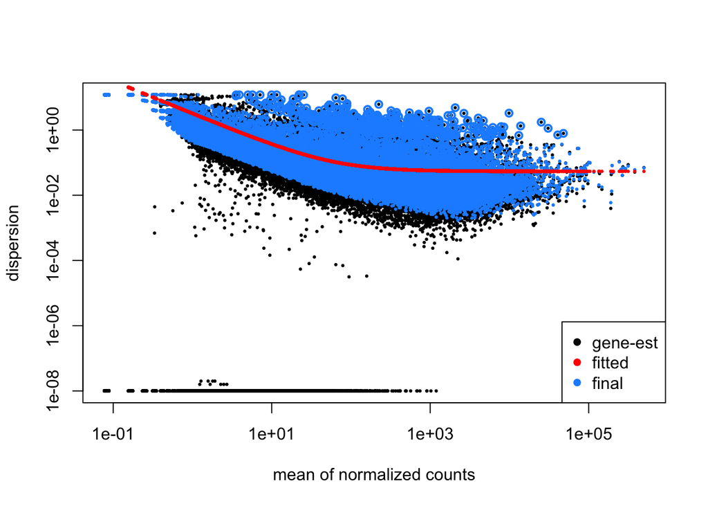

```r
plotDispEsts(dds)
```

DESeq2 estimates dispersion by assuming dispersion is roughly the same for genes that are of the same expression level. However, it does not change dispersion for high count outliers and increases dispersion on low counts to avoid false positives and conserve variability that is likely due to biological instead of technical factors.

Take a look at a gene of interest, NLGN1

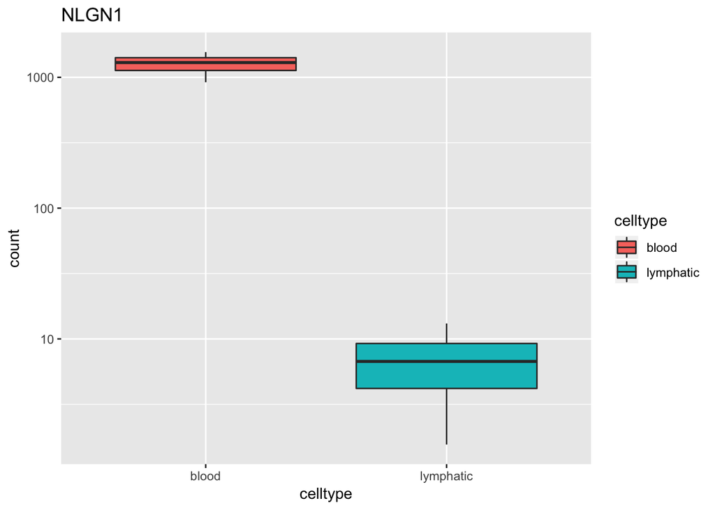

```r
res_annotated %>%
  filter(hgnc_symbol == "NLGN1")
##                  row baseMean log2FoldChange   lfcSE      stat
## 1 ENSG00000169760.17 636.2059       -7.59819 0.29866 -25.44094
##          pvalue          padj ensembl_gene_id entrezgene hgnc_symbol
## 1 8.893274e-143 5.079838e-139 ENSG00000169760      22871       NLGN1
##                                        description
## 1 neuroligin 1 [Source:HGNC Symbol;Acc:HGNC:14291]

#plot the counts of NRG1 between blood and lymph samples
plotCounts(dds, gene = "ENSG00000169760.17", intgroup = "celltype", returnData= TRUE)%>%
  ggplot(aes(celltype, count))+geom_boxplot(aes(fill=celltype))+scale_y_log10()+labs(title="NLGN1")
```

Let’s make plots that show us the relationship between expression of genes and their fold change. An MA plot shows the average expression on the X-axis and the log fold change on the y-axis. A volcano plot shows us genes with high log fold change and low p value. In a volcano plot the log fold change on the X-axis, and the −log10 of the p-value on the Y-axis (the more significant the p-value, the larger the −log10 of that value will be).

Make a new column in res to signify if a gene is significant or not. Then, make an MA plot. Use a log10 scaled x-axis, color-code by whether the gene is significant, and give your plot a title.

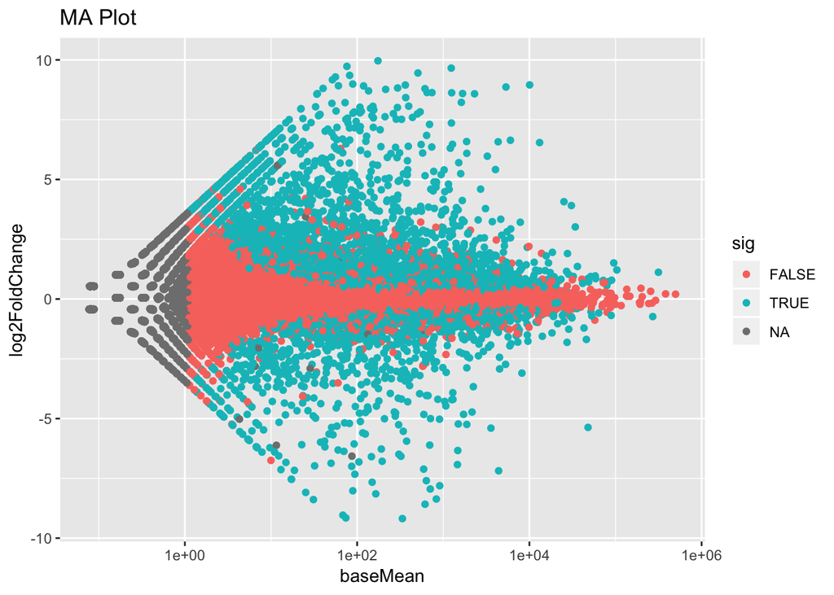

```r
res<- res%>%
  mutate(sig=padj<0.05)

res%>%
  ggplot(aes(x=baseMean, y=log2FoldChange))+geom_point()+aes(color=sig)+labs(title="MA Plot")+scale_x_log10()
## Warning: Transformation introduced infinite values in continuous x-axis
## Warning: Removed 15825 rows containing missing values (geom_point).
```

The gray points are ones that were filtered for testing correction, so really low counts which therefore have no adj p value. DESeq allows us to detect significant differences even if fold change is small, in highly expressed genes with low variance.

**Exercise 4**

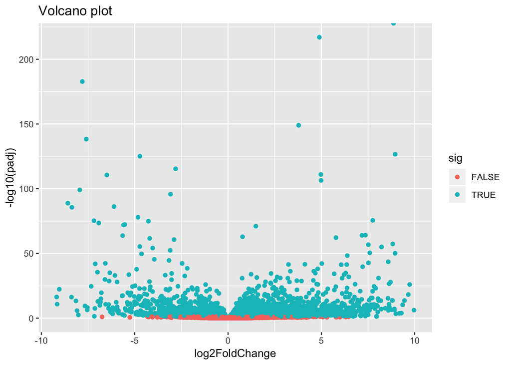

It is very useful to look at a principal component analysis (PCA) to detect batch effect or mislabeled samples. To use PCA, first we must use a transformation of the data. There are several, we will use variance stabilizing.

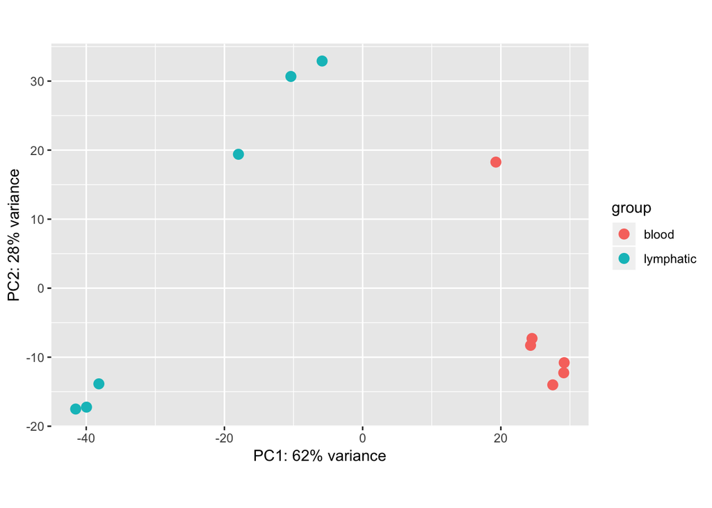

```r
vsdata <- vst(dds, blind=FALSE)
plotPCA(vsdata, intgroup= "celltype")
```

## Pathway analysis

To do pathway analysis on our results, first we must load the datasets that correspond to the pathways.

```r
data("kegg.sets.hs")
data("sigmet.idx.hs")
```

Note that we are loading HUMAN gene sets, if you want to use mouse you need to use kegg.sets.mm- the last two letters are the genus and species you are looking for. We are going to limit our search to kegg sets that have to do with biological processes.

```r
kegg.sets.hs<- kegg.sets.hs[sigmet.idx.hs]
#take a look at this object
lapply(kegg.sets.hs[1:3], head)
## $`hsa00232 Caffeine metabolism`
## [1] "10"   "1544" "1548" "1549" "1553" "7498"
##
## $`hsa00983 Drug metabolism - other enzymes`
## [1] "10"     "1066"   "10720"  "10941"  "151531" "1548"
##
## $`hsa00230 Purine metabolism`
## [1] "100"   "10201" "10606" "10621" "10622" "10623"
```

The gage() function requires a vector of fold changes, where the names of the values are the Entrez gene IDs.

```r
foldchanges<- res_annotated$log2FoldChange
names(foldchanges)<- res_annotated$entrezgene
head(foldchanges)
##      4360    201294      <NA>     64167     22871     10630
##  8.866814  4.892172 -7.808261  3.781955 -7.598190  8.954809
```

Use the function gage to get a new object keggres with significant pathways. We will opt to look for pathways where all the genes are coregulated in the same direction.

```r
keggres<- gage(foldchanges, gsets= kegg.sets.hs, same.dir = TRUE)
lapply(keggres, head)
## $greater
##                                                 p.geomean stat.mean
## hsa04512 ECM-receptor interaction            0.0004023216  3.466041
## hsa04612 Antigen processing and presentation 0.0016826880  3.011077
## hsa04145 Phagosome                           0.0023258172  2.862657
## hsa04020 Calcium signaling pathway           0.0064888503  2.500258
## hsa04510 Focal adhesion                      0.0095394517  2.358113
## hsa04640 Hematopoietic cell lineage          0.0137634777  2.236744
##                                                     p.val      q.val
## hsa04512 ECM-receptor interaction            0.0004023216 0.06396913
## hsa04612 Antigen processing and presentation 0.0016826880 0.12326831
## hsa04145 Phagosome                           0.0023258172 0.12326831
## hsa04020 Calcium signaling pathway           0.0064888503 0.25793180
## hsa04510 Focal adhesion                      0.0095394517 0.30335456
## hsa04640 Hematopoietic cell lineage          0.0137634777 0.34604841
##                                              set.size         exp1
## hsa04512 ECM-receptor interaction                  62 0.0004023216
## hsa04612 Antigen processing and presentation       58 0.0016826880
## hsa04145 Phagosome                                124 0.0023258172
## hsa04020 Calcium signaling pathway                159 0.0064888503
## hsa04510 Focal adhesion                           152 0.0095394517
## hsa04640 Hematopoietic cell lineage                68 0.0137634777
##
## $less
##                                                    p.geomean stat.mean
## hsa03013 RNA transport                            0.02140403 -2.040387
## hsa04914 Progesterone-mediated oocyte maturation  0.02649492 -1.952151
## hsa04110 Cell cycle                               0.03079834 -1.881395
## hsa03040 Spliceosome                              0.03229602 -1.863138
## hsa04740 Olfactory transduction                   0.03279891 -1.847232
## hsa00040 Pentose and glucuronate interconversions 0.03338511 -1.871009
##                                                        p.val     q.val
## hsa03013 RNA transport                            0.02140403 0.7608249
## hsa04914 Progesterone-mediated oocyte maturation  0.02649492 0.7608249
## hsa04110 Cell cycle                               0.03079834 0.7608249
## hsa03040 Spliceosome                              0.03229602 0.7608249
## hsa04740 Olfactory transduction                   0.03279891 0.7608249
## hsa00040 Pentose and glucuronate interconversions 0.03338511 0.7608249
##                                                   set.size       exp1
## hsa03013 RNA transport                                 138 0.02140403
## hsa04914 Progesterone-mediated oocyte maturation        70 0.02649492
## hsa04110 Cell cycle                                    103 0.03079834
## hsa03040 Spliceosome                                   114 0.03229602
## hsa04740 Olfactory transduction                        168 0.03279891
## hsa00040 Pentose and glucuronate interconversions       28 0.03338511
##
## $stats
##                                              stat.mean     exp1
## hsa04512 ECM-receptor interaction             3.466041 3.466041
## hsa04612 Antigen processing and presentation  3.011077 3.011077
## hsa04145 Phagosome                            2.862657 2.862657
## hsa04020 Calcium signaling pathway            2.500258 2.500258
## hsa04510 Focal adhesion                       2.358113 2.358113
## hsa04640 Hematopoietic cell lineage           2.236744 2.236744
```

Same.dir can also be set to false, but gives paths only enriched, not up or down.

```r
keggres<- gage(foldchanges, gsets= kegg.sets.hs, same.dir = FALSE)
lapply(keggres, head)
## $greater
##                                              p.geomean stat.mean
## hsa04514 Cell adhesion molecules (CAMs)   6.092093e-06  4.519081
## hsa04640 Hematopoietic cell lineage       3.880838e-05  4.115711
## hsa04512 ECM-receptor interaction         1.155407e-04  3.836748
## hsa04974 Protein digestion and absorption 2.538733e-04  3.588723
## hsa04020 Calcium signaling pathway        3.370430e-04  3.437737
## hsa00140 Steroid hormone biosynthesis     6.760022e-04  3.320705
##                                                  p.val        q.val
## hsa04514 Cell adhesion molecules (CAMs)   6.092093e-06 0.0009686428
## hsa04640 Hematopoietic cell lineage       3.880838e-05 0.0030852659
## hsa04512 ECM-receptor interaction         1.155407e-04 0.0061236556
## hsa04974 Protein digestion and absorption 2.538733e-04 0.0100914644
## hsa04020 Calcium signaling pathway        3.370430e-04 0.0107179667
## hsa00140 Steroid hormone biosynthesis     6.760022e-04 0.0179140580
##                                           set.size         exp1
## hsa04514 Cell adhesion molecules (CAMs)        112 6.092093e-06
## hsa04640 Hematopoietic cell lineage             68 3.880838e-05
## hsa04512 ECM-receptor interaction               62 1.155407e-04
## hsa04974 Protein digestion and absorption       62 2.538733e-04
## hsa04020 Calcium signaling pathway             159 3.370430e-04
## hsa00140 Steroid hormone biosynthesis           47 6.760022e-04
##
## $stats
##                                           stat.mean     exp1
## hsa04514 Cell adhesion molecules (CAMs)    4.519081 4.519081
## hsa04640 Hematopoietic cell lineage        4.115711 4.115711
## hsa04512 ECM-receptor interaction          3.836748 3.836748
## hsa04974 Protein digestion and absorption  3.588723 3.588723
## hsa04020 Calcium signaling pathway         3.437737 3.437737
## hsa00140 Steroid hormone biosynthesis      3.320705 3.320705
```

Make a new object of significant pathways using sigGeneSet.

```r
keggres_sig<-sigGeneSet(keggres)
## [1] "gs.data needs to be a matrix-like object!"
## [1] "gs.data needs to be a matrix-like object!"
## [1] "there are 8 signficantly two-direction perturbed gene sets"
```

We can also make plots of the pathways and see how individual components of that pathways are up or downregulated through shading in red and green. This will create several files in your base directory plotting the 5 pathways we chose above

```r
#keggrespathways = data.frame(id=rownames(keggres$greater), keggres$greater) %>% tbl_df() %>% filter(row_number()<=5) %>% .$id %>% as.character()
#keggresids = substr(keggrespathways, start=1, stop=8)
#plot_pathway = function(pid) pathview(gene.data=foldchanges, pathway.id=pid, species="hsa", new.signature=FALSE)
#tmp = sapply(keggresids, function(pid) pathview(gene.data=foldchanges, pathway.id=pid, species="hsa"))
```

GO analysis works similarly. First, load the terms. go.set.hs has all GO terms, go.subs.hs has only the BP, CC, and MF, of which we will select biological proccesses.

```r
data("go.sets.hs")
data("go.subs.hs")
gobpsets <- go.sets.hs[go.subs.hs$BP]
```

**Exercise 5**

1. Repeat your pathway analysis of the data using gage, this time searching for the GO terms we read in above. Make a significant gene set object and write the values using write_csv()